# TUGAS MANDIRI PRAKTIKUM MPDW

Muthi’ah Iffa Karimah

2025-09-09

# Input Data

```r
data_udara<- read.csv("C:\\Users\\MUTHI'AH IFFA\\Downloads\\Semester 5\\MPDW\\Praktikum\\Minggu 3\\NewDelhi_Air_quality.csv", header = TRUE, sep = ",")
data_udara
```

```
##     X  AQI       CO      datetime        no2       o3      pm10     pm25
## 1   0 30.2 198.6027 2022-10-21:18 0.04685717 55.78995 10.486722 5.637410
## 2   1 28.2 197.6013 2022-10-21:19 0.04645554 54.93164 10.719325 4.618169
## 3   2 26.6 198.6027 2022-10-21:20 0.04685717 54.64554 11.155578 3.520902
## 4   3 25.0 201.9405 2022-10-21:21 0.04819594 55.07469 11.116206 2.225919
## 5   4 26.0 205.2784 2022-10-21:22 0.04886533 55.78995 10.405250 1.979471
## 6   5 26.0 208.6163 2022-10-21:23 0.05020411 56.50520  9.402518 1.792677
## 7   6 26.0 208.6163 2022-10-22:00 0.05020411 55.78995  8.482822 1.752237
## 8   7 24.0 205.2784 2022-10-22:01 0.05020411 52.92892  7.586667 1.858459
## 9   8 23.0 200.2716 2022-10-22:02 0.04685717 50.06790  7.636587 2.208076
## 10  9 24.0 196.9338 2022-10-22:03 0.04417961 51.49841  8.487648 2.476681
## 11 10 25.0 198.6027 2022-10-22:04 0.04284084 53.64418  9.357371 2.585729
## 12 11 26.0 200.2716 2022-10-22:05 0.04049798 55.78995 10.338728 2.390081
## 13 12 27.0 203.6095 2022-10-22:06 0.04016329 59.36623 10.523314 2.086022
## 14 13 29.0 205.2784 2022-10-22:07 0.03882451 62.22725 10.635970 1.937047
```

[output cut: 131 more lines]

## Persiapan Data

```r
# Install package jika belum ada install.packages(c("ggplot2","tseries","dynlm","dLagM","lmtest","forecast"))

# Load library
library(ggplot2)
library(tseries)
library(dynlm)
library(dLagM)
library(lmtest)
library(forecast)
library(xts)
library(forecast)
library(zoo)
library(car)
library(dynlm)
library(ARDL)
```

## Eksplorasi Data

```r
str(data_udara)
```

```
## 'data.frame':    72 obs. of  12 variables:
##  $ X              : int  0 1 2 3 4 5 6 7 8 9 ...
##  $ AQI            : num  30.2 28.2 26.6 25 26 26 26 24 23 24 ...
##  $ CO             : num  199 198 199 202 205 ...
##  $ datetime       : chr  "2022-10-21:18" "2022-10-21:19" "2022-10-21:20" "2022-10-21:21" ...
##  $ no2            : num  0.0469 0.0465 0.0469 0.0482 0.0489 ...
##  $ o3             : num  55.8 54.9 54.6 55.1 55.8 ...
##  $ pm10           : num  10.5 10.7 11.2 11.1 10.4 ...
##  $ pm25           : num  5.64 4.62 3.52 2.23 1.98 ...
##  $ so2            : num  0.387 0.41 0.402 0.376 0.339 ...
##  $ timestamp_local: chr  "2022-10-21T23:00:00" "2022-10-22T00:00:00" "2022-10-22T01:00:00" "2022-10-22T02:00:00" ...
##  $ timestamp_utc  : chr  "2022-10-21T18:00:00" "2022-10-21T19:00:00" "2022-10-21T20:00:00" "2022-10-21T21:00:00" ...
##  $ ts             : int  1666375200 1666378800 1666382400 1666386000 1666389600 1666393200 1666396800 1666400400 1666404000 1666407600 ...
```

```r
# Buat data subset hanya AQI dan O3
aqi_o3 = data.frame(
  datetime = as.POSIXct(data_udara$ts, origin="1970-01-01", tz="UTC"),
  AQI = data_udara$AQI,
  O3  = data_udara$o3
)
aqi_o3
```

```
##               datetime  AQI       O3
## 1  2022-10-21 18:00:00 30.2 55.78995
## 2  2022-10-21 19:00:00 28.2 54.93164
## 3  2022-10-21 20:00:00 26.6 54.64554
## 4  2022-10-21 21:00:00 25.0 55.07469
## 5  2022-10-21 22:00:00 26.0 55.78995
## 6  2022-10-21 23:00:00 26.0 56.50520
## 7  2022-10-22 00:00:00 26.0 55.78995
## 8  2022-10-22 01:00:00 24.0 52.92892
## 9  2022-10-22 02:00:00 23.0 50.06790
## 10 2022-10-22 03:00:00 24.0 51.49841
## 11 2022-10-22 04:00:00 25.0 53.64418
## 12 2022-10-22 05:00:00 26.0 55.78995
## 13 2022-10-22 06:00:00 27.0 59.36623
## 14 2022-10-22 07:00:00 29.0 62.22725
```

[output cut: 58 more lines]

Dalam tugas ini akan diambil peubah Y adalah nilai AQI dan peubah x nya adalah O3 (ozon). Meski ozon berperan sebagai pelindung di atmosfer bumi, namun ozon akan menjadi berbahaya jika berada di dalam tanah. Karena ozon di dalam tanah terbentuk dari Nitrogen Oksida (NOx) serta senyawa organik volatil (VOC) yang berasal dari pembakaran bahan bakar fosil serta aktivitas manusia. Unsur-unsur ini besifat reakti, mudah bereaksi dengan bahan lain dan bersifat korosif dan berbau menyengat. Sehingga akan berbahaya bila terhirup i konsentrasi tinggi terutama di dekat permukaan, termasuk di dalam tanah.

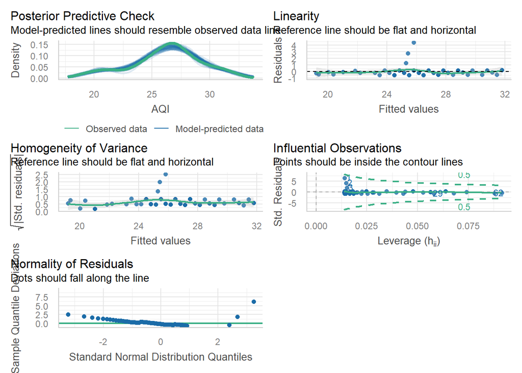

```r
library(performance)
library(see)

# Fit model linear
model = lm(AQI ~ O3, data = aqi_o3)

# Buat diagnostic plot
check_model(model)
```

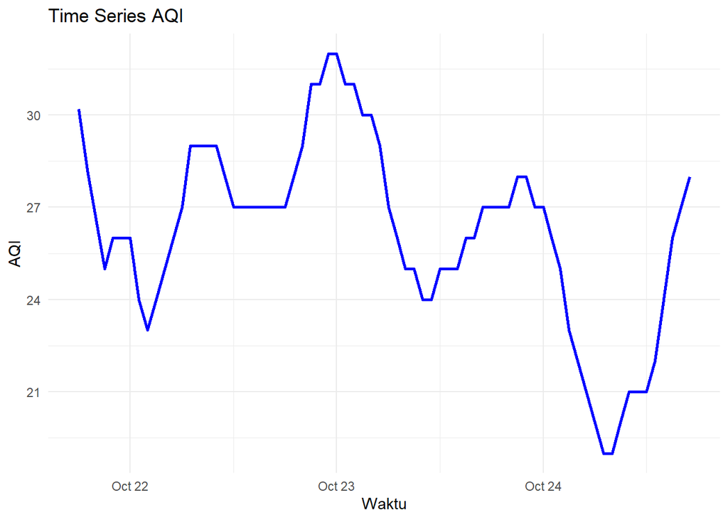

```r
# 1. Plot Time Series AQI
ggplot(aqi_o3, aes(x = datetime, y = AQI)) +
  geom_line(color = "blue", linewidth = 1) +
  labs(title = "Time Series AQI", x = "Waktu", y = "AQI") +
  theme_minimal()
```

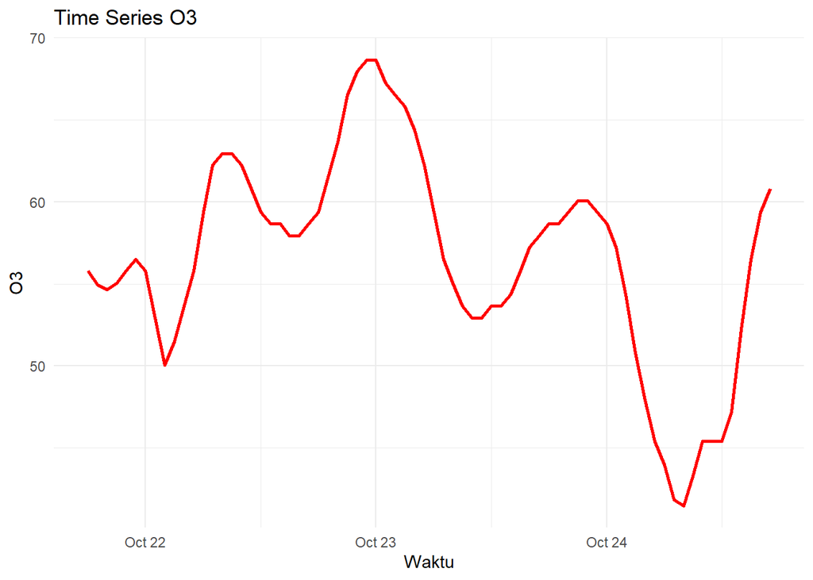

```r
# 2. Plot Time Series O3
ggplot(aqi_o3, aes(x = datetime, y = O3)) +
  geom_line(color = "red", linewidth = 1) +
  labs(title = "Time Series O3", x = "Waktu", y = "O3") +
  theme_minimal()
```

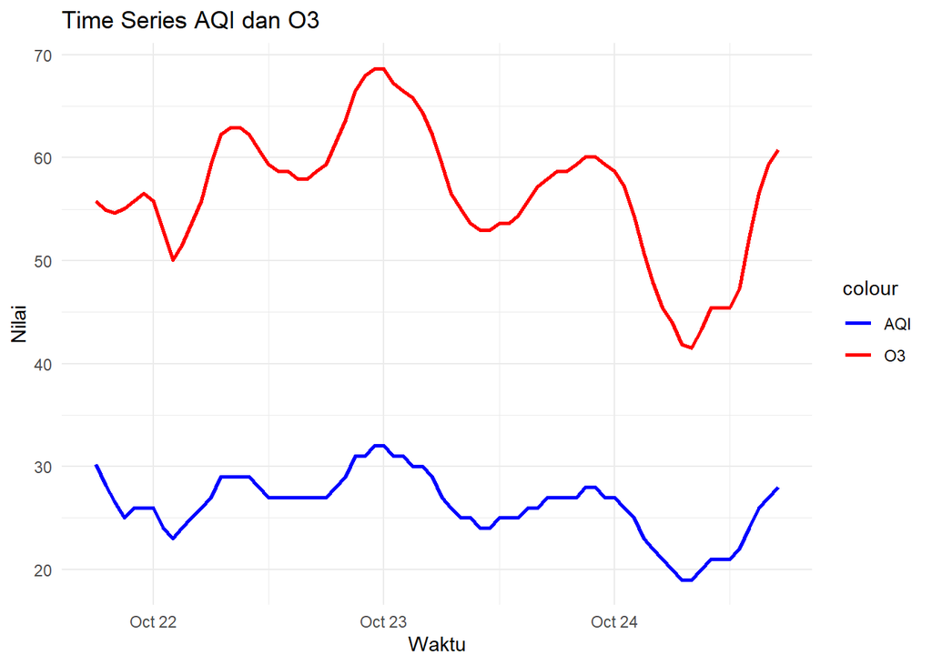

```r
# 3. Gabungan AQI & O3
ggplot(aqi_o3, aes(x = datetime)) +
  geom_line(aes(y = AQI, color = "AQI"), linewidth = 1) +
  geom_line(aes(y = O3, color = "O3"), linewidth = 1) +
  labs(title = "Time Series AQI dan O3", x = "Waktu", y = "Nilai") +
  scale_color_manual(values = c("AQI" = "blue", "O3" = "red")) +
  theme_minimal()
```

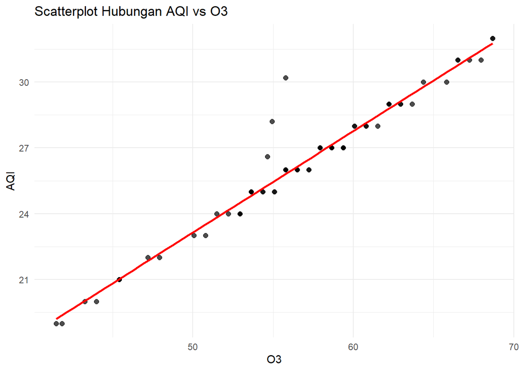

```r
# 4. Scatterplot Hubungan AQI vs O3
ggplot(aqi_o3, aes(x = O3, y = AQI)) +
  geom_point(color = "black", size = 2, alpha = 0.7) +
  geom_smooth(method = "lm", se = FALSE, color = "red") +
  labs(title = "Scatterplot Hubungan AQI vs O3",
       x = "O3", y = "AQI") +
  theme_minimal()
```

#### Statistik Deskriptif

```r
summary(subset(aqi_o3, select = -datetime))
```

```
##       AQI              O3
##  Min.   :19.00   Min.   :41.48
##  1st Qu.:25.00   1st Qu.:53.64
##  Median :27.00   Median :57.22
##  Mean   :26.18   Mean   :56.57
##  3rd Qu.:28.00   3rd Qu.:60.08
##  Max.   :32.00   Max.   :68.66
```

#### Distribusi Data

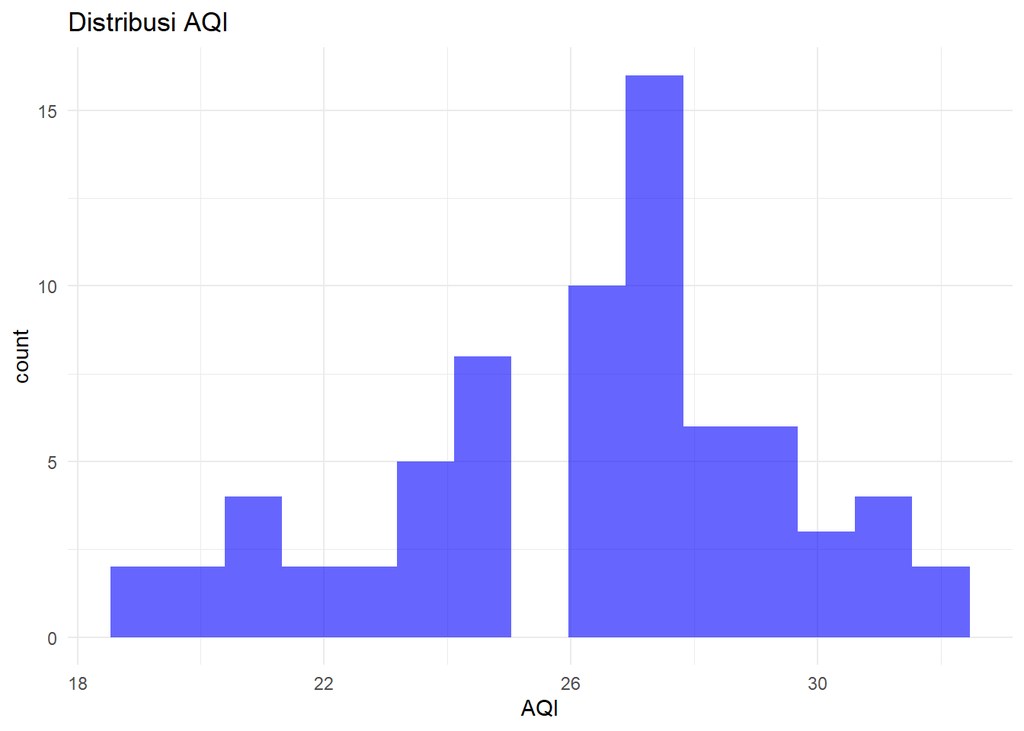

```r
# Histogram
ggplot(aqi_o3, aes(x = AQI)) +
  geom_histogram(bins = 15, fill="blue", alpha=0.6) +
  labs(title="Distribusi AQI") +
  theme_minimal()
```

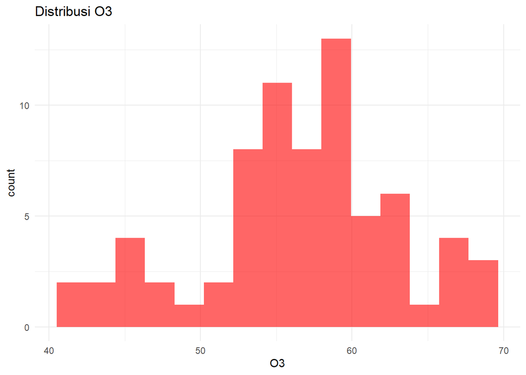

```r
ggplot(aqi_o3, aes(x = O3)) +
  geom_histogram(bins = 15, fill="red", alpha=0.6) +
  labs(title="Distribusi O3") +
  theme_minimal()
```

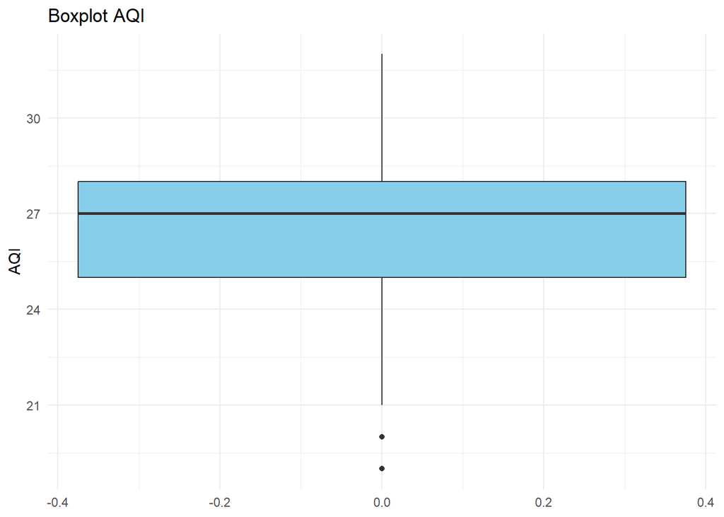

```r
# Boxplot (cek outlier)
ggplot(aqi_o3, aes(y = AQI)) +
  geom_boxplot(fill="skyblue") +
  labs(title="Boxplot AQI") +
  theme_minimal()
```

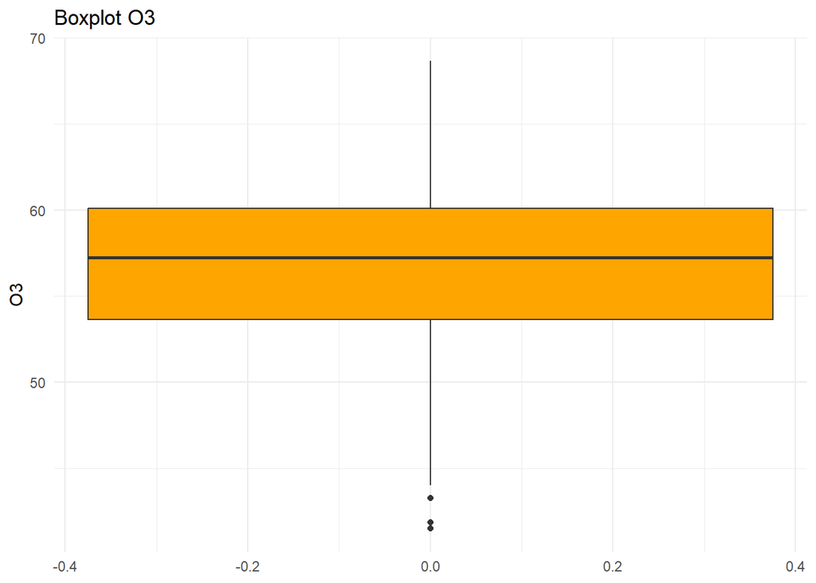

```r
ggplot(aqi_o3, aes(y = O3)) +
  geom_boxplot(fill="orange") +
  labs(title="Boxplot O3") +
  theme_minimal()
```

#### Autokorelasi (ACF)

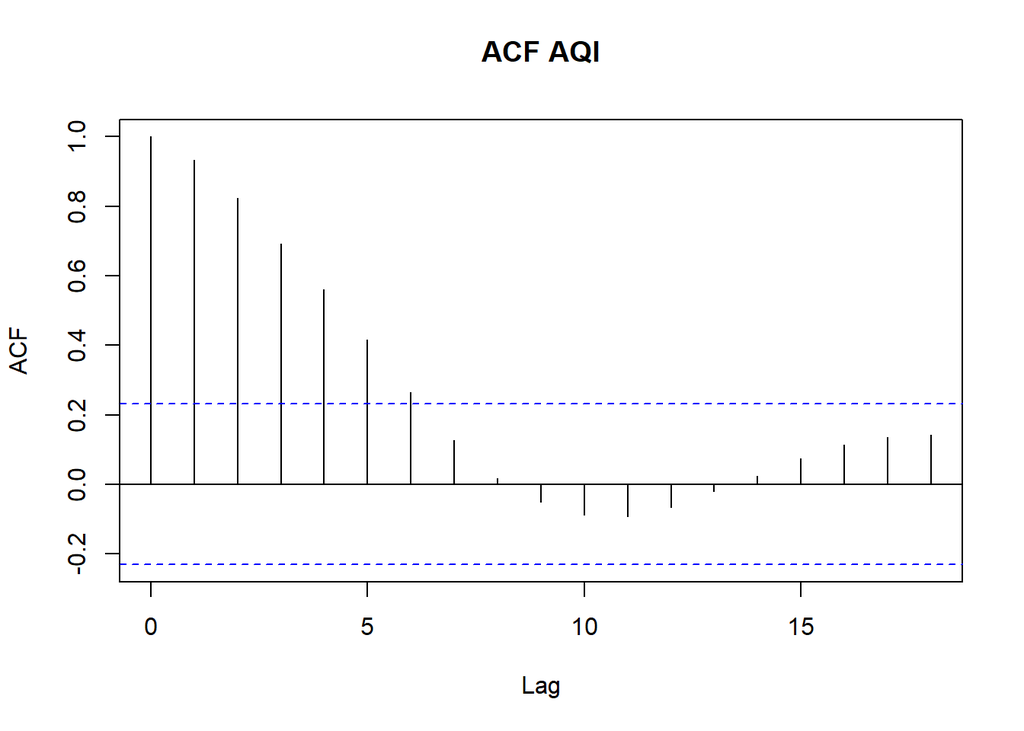

```r
# Cek asumsi autokorelasi dengan ACF
acf(aqi_o3$AQI, main="ACF AQI")
```

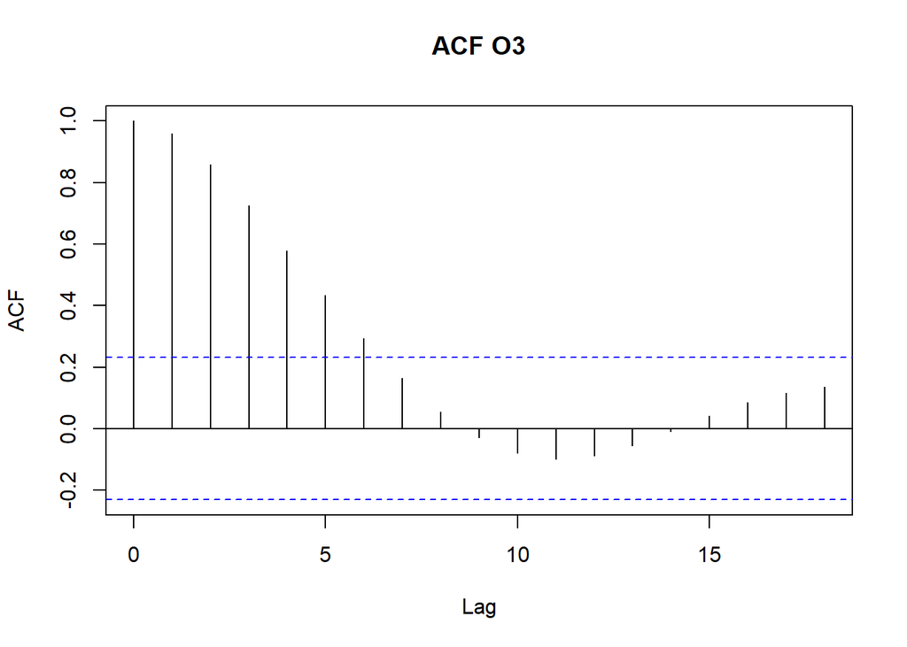

```r
acf(aqi_o3$O3, main="ACF O3")
```

Baik ACF untuk O3 dan AQI keduanya terindikasi autokorelasi

#### Lag Scatterplot

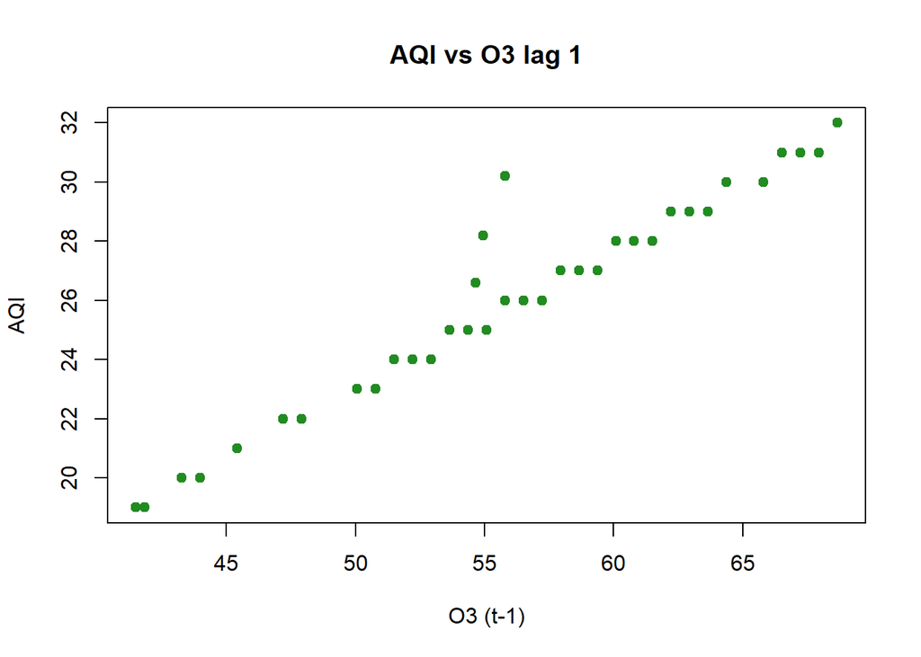

```r
# misal lag 1 untuk O3
lag1_O3 <- stats::lag(aqi_o3$O3, -1)
plot(lag1_O3, aqi_o3$AQI,
     main="AQI vs O3 lag 1",
     xlab="O3 (t-1)", ylab="AQI",
     pch=19, col="forestgreen")
```

Berdasarkan scatterplot AQI vs O3 adalah linear

### Boxplot

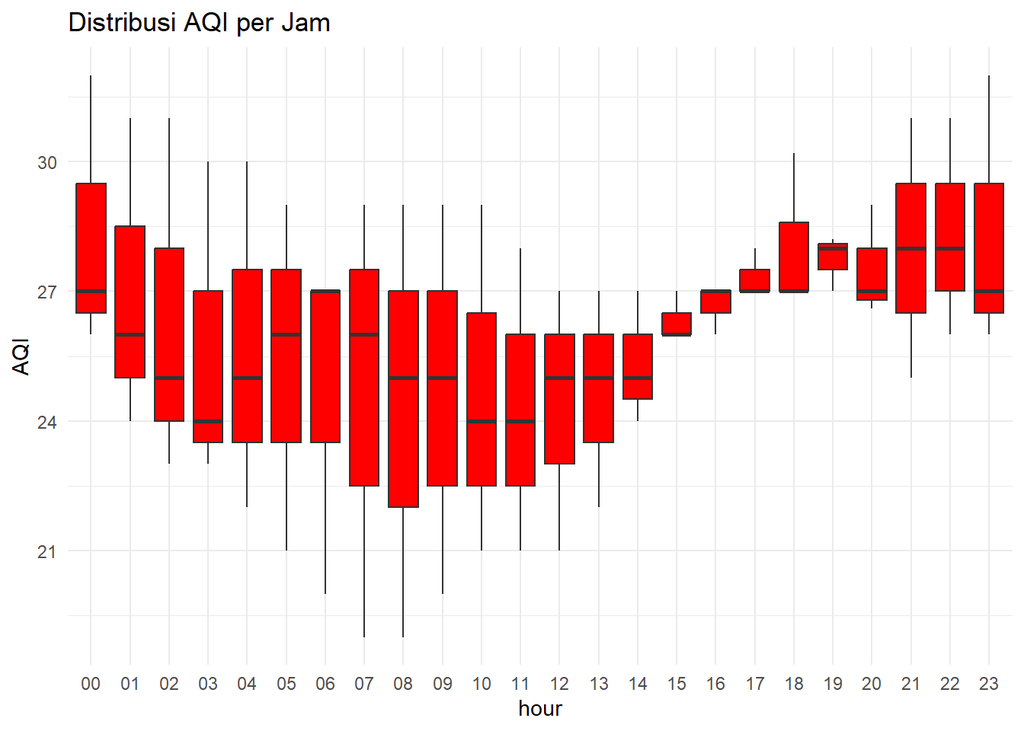

```r
# Boxplot Distribusi AQI (dengan boxplot per jam)
aqi_o3$hour <- format(aqi_o3$datetime, "%H")

ggplot(aqi_o3, aes(x = hour, y = AQI)) +
  geom_boxplot(fill="red") +
  labs(title="Distribusi AQI per Jam") +
  theme_minimal()
```

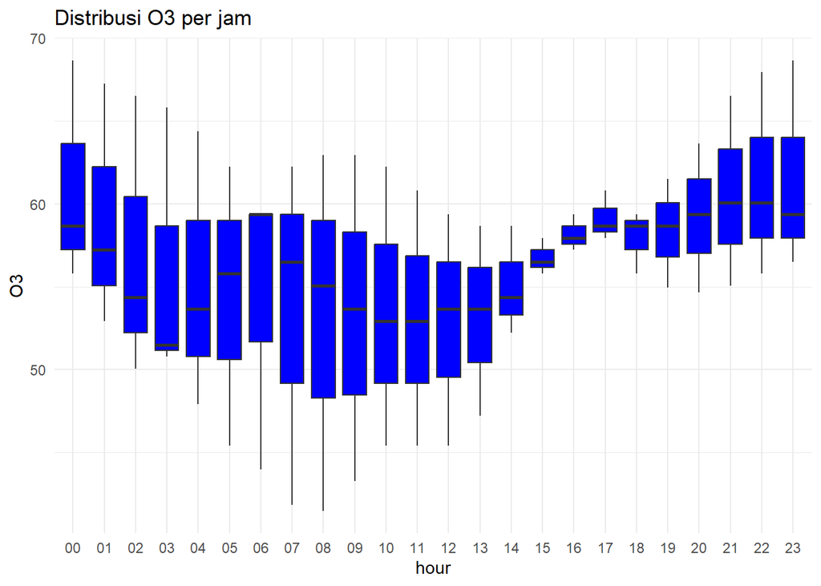

```r
# Boxplot Distribusi O3 (dengan boxplot per jam)
ggplot(aqi_o3, aes(x = hour, y = O3)) +
  geom_boxplot(fill="blue") +
  labs(title="Distribusi O3 per jam") +
  theme_minimal()
```

### Cek Seasonal

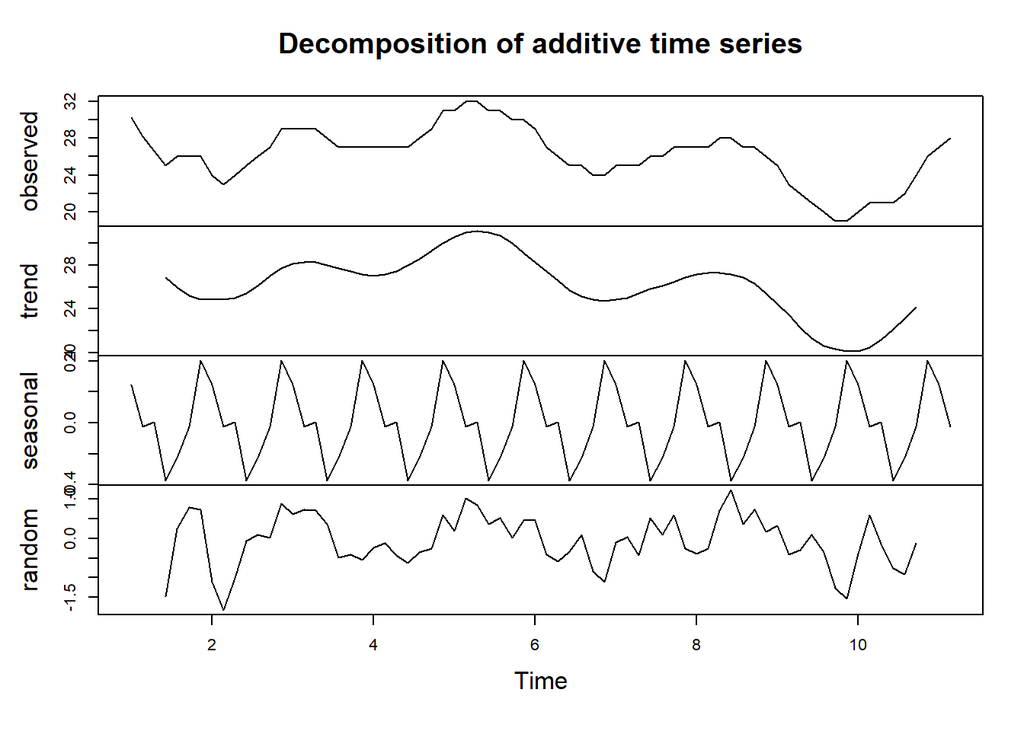

```r
# Ubah data jadi ts (misal datanya harian dengan periode mingguan = 7)
aqi_ts <- ts(aqi_o3$AQI, frequency = 7)

# Decompose
decomp <- decompose(aqi_ts, type = "additive")
plot(decomp)
```

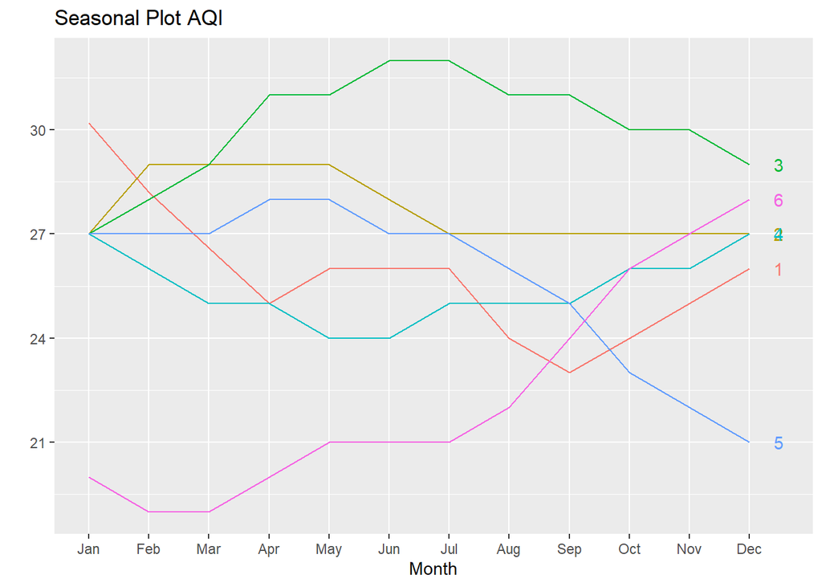

```r
# Pola musiman AQI
aqi_ts <- ts(aqi_o3$AQI, frequency = 12) # contoh bulanan
ggseasonplot(aqi_ts, year.labels = TRUE, main = "Seasonal Plot AQI")
```

```r
# Hitung rolling variance (window 12, misal bulanan)
aqi_var <- rollapply(aqi_o3$AQI, width=12, FUN=var, fill=NA, align="right")
o3_var  <- rollapply(aqi_o3$O3,  width=12, FUN=var, fill=NA, align="right")
```

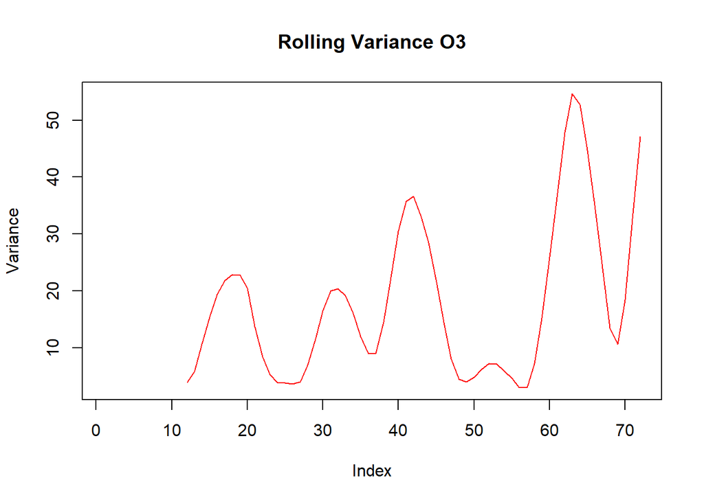

```r
# Plot rolling variance
plot(o3_var,  type="l", col="red",  main="Rolling Variance O3", ylab="Variance", xlab="Index")
```

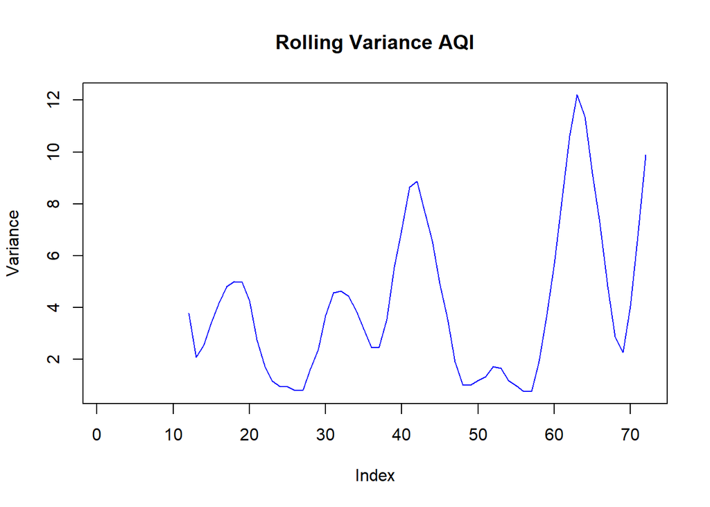

```r
# Plot rolling variance
plot(aqi_var, type="l", col="blue", main="Rolling Variance AQI", ylab="Variance", xlab="Index")
```

# Cek Asumsi

H0: Data tidak stationer (ada unit root)

H1: Data stationer

p-value < 0.05 tolak H0

```r
# Regresi linear sederhana
model = lm(AQI ~ O3, data = aqi_o3)
summary(model)
```

```
##
## Call:
## lm(formula = AQI ~ O3, data = aqi_o3)
##
## Residuals:
##     Min      1Q  Median      3Q     Max
## -0.5039 -0.4436 -0.1381  0.1810  4.3810
##
## Coefficients:
##             Estimate Std. Error t value Pr(>|t|)
## (Intercept)  0.02128    0.73771   0.029    0.977
## O3           0.46241    0.01296  35.685   <2e-16 ***
## ---
## Signif. codes:  0 '***' 0.001 '**' 0.01 '*' 0.05 '.' 0.1 ' ' 1
##
## Residual standard error: 0.7022 on 70 degrees of freedom
## Multiple R-squared:  0.9479, Adjusted R-squared:  0.9472
## F-statistic:  1273 on 1 and 70 DF,  p-value: < 2.2e-16
```

```r
# Uji stationer
# Konversi ke time series
aqi_ts <- ts(aqi_o3$AQI, frequency = 12)
o3_ts  <- ts(aqi_o3$O3, frequency = 12)

# Uji stasioneritas dengan ADF
adf_aqi = adf.test(na.omit(aqi_ts))
adf_o3 = adf.test(na.omit(o3_ts))

adf_aqi
```

```
##
##  Augmented Dickey-Fuller Test
##
## data:  na.omit(aqi_ts)
## Dickey-Fuller = -3.4572, Lag order = 4, p-value = 0.05349
## alternative hypothesis: stationary
```

```r
adf_o3
```

```
##
##  Augmented Dickey-Fuller Test
##
## data:  na.omit(o3_ts)
## Dickey-Fuller = -3.0518, Lag order = 4, p-value = 0.1471
## alternative hypothesis: stationary
```

```r
if(adf_aqi$p.value < 0.05){
  cat("AQI stasioner (p =", adf_aqi$p.value, ")\n")
} else {
  cat("AQI TIDAK stasioner (p =", adf_aqi$p.value, ")\n")
}
```

```
## AQI TIDAK stasioner (p = 0.05349047 )
```

```r
if(adf_o3$p.value < 0.05){
  cat("O3 stasioner (p =", adf_o3$p.value, ")\n")
} else {
  cat("O3 TIDAK stasioner (p =", adf_o3$p.value, ")\n")
}
```

```
## O3 TIDAK stasioner (p = 0.1470529 )
```

```r
# Uji Heteroskeditas
bp = bptest(model)
bp
```

```
##
##  studentized Breusch-Pagan test
##
## data:  model
## BP = 0.039736, df = 1, p-value = 0.842
```

```r
if(bp$p.value < 0.05){
  cat("Heteroskedastisitas TERDETEKSI (p =", bp$p.value, ")\n")
} else {
  cat("Tidak ada heteroskedastisitas (p =", bp$p.value, ")\n")
}
```

```
## Tidak ada heteroskedastisitas (p = 0.8419971 )
```

```r
dw = dwtest(model)
dw
```

```
##
##  Durbin-Watson test
##
## data:  model
## DW = 0.54636, p-value = 3.207e-14
## alternative hypothesis: true autocorrelation is greater than 0
```

```r
if(dw$p.value < 0.05){
  cat("Autokorelasi TERDETEKSI (p =", dw$p.value, ")\n")
} else {
  cat("Tidak ada autokorelasi (p =", dw$p.value, ")\n")
}
```

```
## Autokorelasi TERDETEKSI (p = 3.20666e-14 )
```

#### Transformasi peubah X dan Y

```r
# Transformasi log
aqi.log = log(aqi_o3$AQI)
o3.log  = log(aqi_o3$O3)

# Uji stationer
model.log = lm(aqi.log~ o3.log, data = aqi_o3)
summary(model.log)
```

```
##
## Call:
## lm(formula = aqi.log ~ o3.log, data = aqi_o3)
##
## Residuals:
##       Min        1Q    Median        3Q       Max
## -0.020615 -0.015948 -0.005027  0.006839  0.157162
##
## Coefficients:
##             Estimate Std. Error t value Pr(>|t|)
## (Intercept)  -0.7941     0.1044  -7.606 9.69e-11 ***
## o3.log        1.0058     0.0259  38.829  < 2e-16 ***
## ---
## Signif. codes:  0 '***' 0.001 '**' 0.01 '*' 0.05 '.' 0.1 ' ' 1
##
## Residual standard error: 0.02579 on 70 degrees of freedom
## Multiple R-squared:  0.9556, Adjusted R-squared:  0.955
## F-statistic:  1508 on 1 and 70 DF,  p-value: < 2.2e-16
```

#### Uji asumsi ulang

```r
# Uji Stationer
adf.aqi2 = adf.test(na.omit(aqi.log))
adf.o32 = adf.test(na.omit(o3.log))
adf.aqi2
```

```
##
##  Augmented Dickey-Fuller Test
##
## data:  na.omit(aqi.log)
## Dickey-Fuller = -3.6232, Lag order = 4, p-value = 0.03763
## alternative hypothesis: stationary
```

```r
adf.o32
```

```
##
##  Augmented Dickey-Fuller Test
##
## data:  na.omit(o3.log)
## Dickey-Fuller = -3.2523, Lag order = 4, p-value = 0.08638
## alternative hypothesis: stationary
```

```r
cat("Stasioner logAQI:", ifelse(adf.aqi2$p.value < 0.05, "✅ Stasioner", "❌ Tidak Stasioner"),
    "(p =", adf.aqi2$p.value, ")\n")
```

```
## Stasioner logAQI: ✅ Stasioner (p = 0.03763491 )
```

```r
cat("Stasioner logO3 :", ifelse(adf.o32$p.value < 0.05, "✅ Stasioner", "❌ Tidak Stasioner"),
    "(p =", adf.o32$p.value, ")\n")
```

```
## Stasioner logO3 : ❌ Tidak Stasioner (p = 0.08637699 )
```

```r
# Uji heteroskeditas
bp2 = bptest(model.log)
cat("Heteroskedastisitas:", ifelse(bp$p.value > 0.05,
    "✅ Tidak ada heteroskedastisitas",
    "❌ Ada heteroskedastisitas"),
    "(p =", bp$p.value, ")\n")
```

```
## Heteroskedastisitas: ✅ Tidak ada heteroskedastisitas (p = 0.8419971 )
```

```r
# Uji Autokorelasi
dw2 = dwtest(model.log)
cat("Autokorelasi:", ifelse(dw$p.value > 0.05,
    "✅ Tidak ada autokorelasi",
    "❌ Autokorelasi terdeteksi"),
    "(p =", dw$p.value, ")\n")
```

```
## Autokorelasi: ❌ Autokorelasi terdeteksi (p = 3.20666e-14 )
```

```r
# Uji Normalitas
shapiro = shapiro.test(residuals(model.log))
cat("Normalitas residual:", ifelse(shapiro$p.value > 0.05,
    "✅ Residual berdistribusi normal",
    "❌ Residual tidak normal"),
    "(p =", shapiro$p.value, ")\n")
```

```
## Normalitas residual: ❌ Residual tidak normal (p = 9.870481e-14 )
```

### Penangan Autokorelasi

```r
# Install jika belum ada
# install.packages("orcutt")

library(orcutt)

# Model awal (sudah log transform)
model.log = lm(aqi.log ~ o3.log, data = aqi_o3)

# Terapkan Cochrane-Orcutt
co_model = cochrane.orcutt(model.log)

summary(co_model)
```

```
## Call:
## lm(formula = aqi.log ~ o3.log, data = aqi_o3)
##
##              Estimate Std. Error t value  Pr(>|t|)
## (Intercept) -0.814069   0.104399  -7.606 9.694e-11 ***
## o3.log       1.009692   0.025902  38.829 < 2.2e-16 ***
## ---
## Signif. codes:  0 '***' 0.001 '**' 0.01 '*' 0.05 '.' 0.1 ' ' 1
##
## Residual standard error: 0.013 on 69 degrees of freedom
## Multiple R-squared:  0.9661 ,  Adjusted R-squared:  0.9656
## F-statistic: 1964.8 on 1 and 69 DF,  p-value: < 1.959e-52
##
## Durbin-Watson statistic
## (original):    0.55318 , p-value: 4.741e-14
## (transformed): 2.68580 , p-value: 9.98e-01
```

```r
# Uji lagi autokorelasi
library(lmtest)
dw_co = dwtest(co_model)
cat("Autokorelasi setelah Cochrane-Orcutt:",
    ifelse(dw_co$p.value > 0.05, "✅ Tidak ada autokorelasi",
           "❌ Autokorelasi masih ada"),
    "(p =", dw_co$p.value, ")\n")
```

```
## Autokorelasi setelah Cochrane-Orcutt: ✅ Tidak ada autokorelasi (p = 0.9979682 )
```

### Penanganan Normalitas Residual

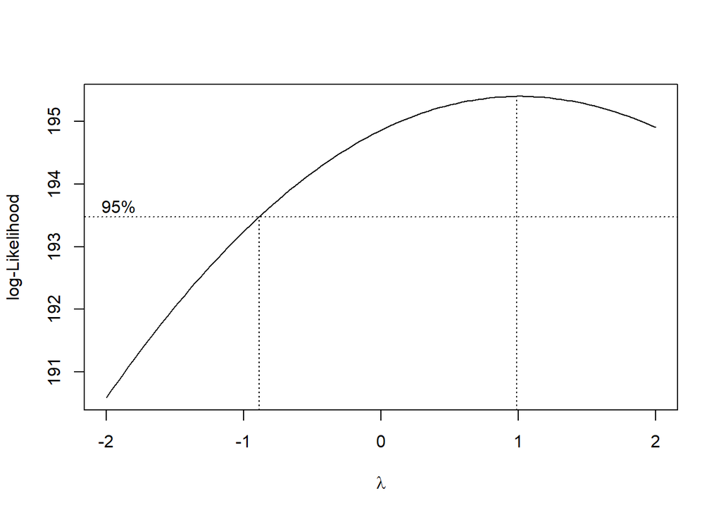

```r
library(MASS)

# Box-Cox untuk cari lambda terbaik
boxcox(model.log, lambda = seq(-2, 2, 0.1))
```

```r
# Misal dari grafik, lambda ≈ 0 (log) atau 0.5 (sqrt)
# Kalau misal λ=0.5 → transformasi sqrt
aqi_o3$AQI_sqrt = sqrt(aqi_o3$AQI)
aqi_o3$O3_sqrt  = sqrt(aqi_o3$O3)

model.sqrt = lm(AQI_sqrt ~ O3_sqrt, data = aqi_o3)
summary(model.sqrt)
```

```
##
## Call:
## lm(formula = AQI_sqrt ~ O3_sqrt, data = aqi_o3)
##
## Residuals:
##      Min       1Q   Median       3Q      Max
## -0.05094 -0.04087 -0.01315  0.01834  0.41477
##
## Coefficients:
##             Estimate Std. Error t value Pr(>|t|)
## (Intercept) -0.01249    0.13801  -0.091    0.928
## O3_sqrt      0.68188    0.01835  37.161   <2e-16 ***
## ---
## Signif. codes:  0 '***' 0.001 '**' 0.01 '*' 0.05 '.' 0.1 ' ' 1
##
## Residual standard error: 0.06724 on 70 degrees of freedom
## Multiple R-squared:  0.9518, Adjusted R-squared:  0.9511
## F-statistic:  1381 on 1 and 70 DF,  p-value: < 2.2e-16
```

```r
# Cek normalitas residual lagi
shapiro = shapiro.test(residuals(model.sqrt))
cat("Normalitas residual setelah transformasi:",
    ifelse(shapiro$p.value > 0.05,
           "✅ Residual normal",
           "❌ Residual tidak normal"),
    "(p =", shapiro$p.value, ")\n")
```

```
## Normalitas residual setelah transformasi: ❌ Residual tidak normal (p = 6.510119e-14 )
```

```r
# Differencing pada O3 log
o3.diff = diff(o3.log)   # langsung diff vektor o3.log

# Uji ADF pada hasil differencing
library(tseries)
adf_o3_diff = adf.test(na.omit(o3.diff))

cat("Stasioner log(O3) differenced:",
    ifelse(adf_o3_diff$p.value < 0.05,
           "✅ Stasioner",
           "❌ Tidak stasioner"),
    "(p =", adf_o3_diff$p.value, ")\n")
```

```
## Stasioner log(O3) differenced: ❌ Tidak stasioner (p = 0.1443159 )
```

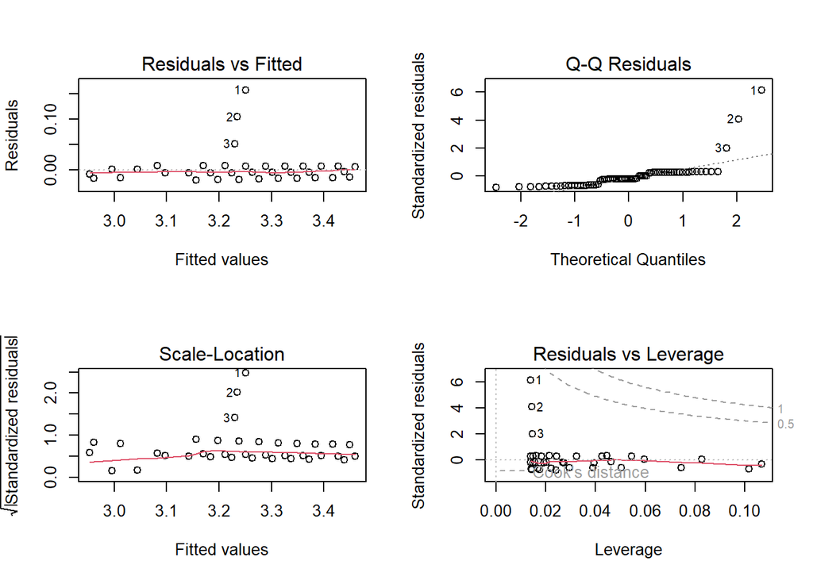

```r
par(mfrow=c(2,2))
plot(model.log)
```

# Pembagian Data

```r
n = (aqi_o3)
n
```

```
##               datetime  AQI       O3 hour AQI_sqrt  O3_sqrt
## 1  2022-10-21 18:00:00 30.2 55.78995   18 5.495453 7.469267
## 2  2022-10-21 19:00:00 28.2 54.93164   19 5.310367 7.411588
## 3  2022-10-21 20:00:00 26.6 54.64554   20 5.157519 7.392262
## 4  2022-10-21 21:00:00 25.0 55.07469   21 5.000000 7.421232
## 5  2022-10-21 22:00:00 26.0 55.78995   22 5.099020 7.469267
## 6  2022-10-21 23:00:00 26.0 56.50520   23 5.099020 7.516994
## 7  2022-10-22 00:00:00 26.0 55.78995   00 5.099020 7.469267
## 8  2022-10-22 01:00:00 24.0 52.92892   01 4.898979 7.275227
## 9  2022-10-22 02:00:00 23.0 50.06790   02 4.795832 7.075867
## 10 2022-10-22 03:00:00 24.0 51.49841   03 4.898979 7.176239
## 11 2022-10-22 04:00:00 25.0 53.64418   04 5.000000 7.324219
## 12 2022-10-22 05:00:00 26.0 55.78995   05 5.099020 7.469267
## 13 2022-10-22 06:00:00 27.0 59.36623   06 5.196152 7.704948
## 14 2022-10-22 07:00:00 29.0 62.22725   07 5.385165 7.888425
```

[output cut: 58 more lines]

```r
library(dynlm)
library(dplyr)
library(lmtest)
library(Metrics)
# Buat dataframe log
df_log = data.frame(
  AQI_log = log(aqi_o3$AQI),
  O3_log  = log(aqi_o3$O3)
)

# split data
n = nrow(df_log)
train_n = floor(0.7 * n)
train = df_log[1:train_n, ]
test  = df_log[(train_n+1):n, ]

train_ts <- ts(train, frequency = 12)
test_ts  <- ts(test, frequency = 12)
```

Proporsi 70:30 dipilih karena jumlah data relatif kecil (72 observasi), sehingga 30% uji (22 data) memberikan evaluasi lebih reliabel dibanding hanya 20% uji (14 data). Ini menjaga keseimbangan antara data latih yang cukup untuk membangun model dan data uji yang cukup untuk mengukur kinerja model.

```r
# Data time series
train_ts = ts(train)
test. = ts(test)
data.ts = ts(df_log)
```

# Koyck

### Pemodelan

```r
# MODEL KOYCK
model.koyck = koyckDlm(x = train$O3_log, y = train$AQI_log)
summary(model.koyck)
```

```
##
## Call:
## "Y ~ (Intercept) + Y.1 + X.t"
##
## Residuals:
##        Min         1Q     Median         3Q        Max
## -0.0473770 -0.0098381  0.0005975  0.0094096  0.0374549
##
## Coefficients:
##             Estimate Std. Error t value Pr(>|t|)
## (Intercept) -0.33478    0.16279  -2.056   0.0454 *
## Y.1          0.42859    0.08665   4.946 1.05e-05 ***
## X.t          0.54519    0.09402   5.798 5.80e-07 ***
## ---
## Signif. codes:  0 '***' 0.001 '**' 0.01 '*' 0.05 '.' 0.1 ' ' 1
##
## Residual standard error: 0.01946 on 46 degrees of freedom
## Multiple R-Squared: 0.9462,  Adjusted R-squared: 0.9438
## Wald test: 368.5 on 2 and 46 DF,  p-value: < 2.2e-16
##
## Diagnostic tests:
## NULL
##
##                               alpha      beta       phi
## Geometric coefficients:  -0.5858872 0.5451889 0.4285894
```

```r
AIC(model.koyck)
```

```
## [1] -242.1171
```

```r
BIC(model.koyck)
```

```
## [1] -234.5498
```

hasil summary didapatkan Y_duga_t = -0.33478 + 0.54519Xt + 0.42859Yt

- Koefisien Xt (0.54519) signifikan, artinya X berpengaruh terhaadp U
- Koefisien Yt-1 (0.42859) signifikan, ini merupakan estimasi untuk λ. Nilai ini menunjukkan sekitar 42% dari efek di periode sebelumnya masih “terbawa” saat ini

### Peramalan dan Akurasi

```r
# Peramalan y untuk 5 periode kedepan dengan menggunakan model koyck
library(dLagM)
fore.koyck = dLagM::forecast(model = model.koyck, x = train$O3_log, h = 5) # Membandingkan dengan data testing
fore.koyck
```

```
## $forecasts
## [1] 3.270307 3.250912 3.239753 3.239235 3.246048
##
## $call
## forecast.koyckDlm(model = model.koyck, x = train$O3_log, h = 5)
##
## attr(,"class")
## [1] "forecast.koyckDlm" "dLagM"
```

```r
# Cek nilai MAPE
mape.koyck = MAPE(model.koyck)
mape.koyck #data test
```

```
##                    MAPE
## model.koyck 0.004403018
```

```r
# Akurasi ata training
GoF(model.koyck)
```

```
##              n        MAE           MPE        MAPE       sMAPE     MASE
## model.koyck 49 0.01445862 -4.912283e-05 0.004403018 0.004400766 0.597827
##                      MSE     MRAE    GMRAE
## model.koyck 0.0003553854 21602125 1840.982
```

# Regression with Distributed Lag

### Pemodelan (Lag = 2)

```r
model.dlm = dlm(x = train$O3_log, y = train$AQI_log, q = 1)
summary(model.dlm)
```

```
##
## Call:
## lm(formula = model.formula, data = design)
##
## Residuals:
##       Min        1Q    Median        3Q       Max
## -0.021971 -0.012155 -0.002503  0.007252  0.102908
##
## Coefficients:
##               Estimate Std. Error t value Pr(>|t|)
## (Intercept) -6.888e-01  1.487e-01  -4.631 2.99e-05 ***
## x.t          9.799e-01  1.119e-01   8.758 2.32e-11 ***
## x.1         -4.518e-05  1.115e-01   0.000        1
## ---
## Signif. codes:  0 '***' 0.001 '**' 0.01 '*' 0.05 '.' 0.1 ' ' 1
##
## Residual standard error: 0.02033 on 46 degrees of freedom
## Multiple R-squared:  0.9412, Adjusted R-squared:  0.9387
## F-statistic: 368.3 on 2 and 46 DF,  p-value: < 2.2e-16
##
## AIC and BIC values for the model:
##         AIC       BIC
## 1 -237.8021 -230.2349
```

```r
model.dlm = dlm(x = train$O3_log, y = train$AQI_log, q = 2)
summary(model.dlm)
```

```
##
## Call:
## lm(formula = model.formula, data = design)
##
## Residuals:
##      Min       1Q   Median       3Q      Max
## -0.01770 -0.01256 -0.00142  0.00917  0.05349
##
## Coefficients:
##              Estimate Std. Error t value Pr(>|t|)
## (Intercept) -0.767985   0.110632  -6.942 1.39e-08 ***
## x.t          1.035537   0.123678   8.373 1.18e-10 ***
## x.1         -0.028351   0.221844  -0.128    0.899
## x.2         -0.008469   0.122504  -0.069    0.945
## ---
## Signif. codes:  0 '***' 0.001 '**' 0.01 '*' 0.05 '.' 0.1 ' ' 1
##
## Residual standard error: 0.01348 on 44 degrees of freedom
## Multiple R-squared:  0.9752, Adjusted R-squared:  0.9735
## F-statistic: 575.7 on 3 and 44 DF,  p-value: < 2.2e-16
##
## AIC and BIC values for the model:
##         AIC       BIC
## 1 -271.3783 -262.0223
```

```r
AIC(model.dlm)
```

```
## [1] -271.3783
```

```r
BIC(model.dlm)
```

```
## [1] -262.0223
```

### Peramalan dan Akurasi

```r
fore.dlm = dLagM::forecast(model = model.dlm, x = train$O3_log, h = 5) # Membandingkan dengan data testing
fore.dlm
```

```
## $forecasts
## [1] 3.246604 3.231967 3.227422 3.235802 3.248987
##
## $call
## forecast.dlm(model = model.dlm, x = train$O3_log, h = 5)
##
## attr(,"class")
## [1] "forecast.dlm" "dLagM"
```

```r
mape.dlm = MAPE(model.dlm)
mape.dlm
```

```
##                  MAPE
## model.dlm 0.003059721
```

### Lag Optimum

kita dapat meminta R untuk mencari nilai yang optimal secara otomatis berdasarkan kriteria informasi seperti AIC. AIC menyeimbangkan antara kecocokan model dengan kompleksitasnya.

```r
train_sub <- train[, c("AQI_log", "O3_log")]
# Penentuan Lag Optimum
finiteDLMauto(formula = AQI_log ~ O3_log,
              data = train_sub, q.min = 1, q.max = 10,
              model.type = "dlm", error.type = "AIC", trace = TRUE)
```

```
##    q - k    MASE       AIC       BIC    GMRAE   MBRAE R.Adj.Sq  Ljung-Box
## 3      3 0.39444 -284.7217 -273.6208 1836.352 0.48939  0.98302 0.14598099
## 4      4 0.39409 -277.6753 -264.8748 2324.129 0.49314  0.98304 0.21155323
## 5      5 0.37104 -272.5562 -258.1029 1977.364 0.48976  0.98401 0.21808396
## 2      2 0.42909 -271.3783 -262.0223 1705.440 0.48224  0.97346 0.09693428
## 6      6 0.36809 -263.2521 -247.1944 1438.333 0.47749  0.98343 0.23443482
## 7      7 0.38346 -255.7600 -238.1480 1753.463 0.48394  0.98349 0.38846689
## 8      8 0.39442 -249.9787 -230.8643 2618.044 0.50855  0.98342 0.48254949
## 10    10 0.35467 -244.0683 -222.1129 3527.973 0.49992  0.98439 0.37850557
## 9      9 0.38981 -242.9655 -222.4027 3023.208 0.50479  0.98187 0.96297827
## 1      1 0.51444 -237.8022 -230.2349 1748.893 0.36813  0.93866 0.14745321
```

```r
model.dlm2 = dlm(x = train$O3_log, y = train$AQI_log, q = 10)
summary(model.dlm2)
```

```
##
## Call:
## lm(formula = model.formula, data = design)
##
## Residuals:
##       Min        1Q    Median        3Q       Max
## -0.015661 -0.007345  0.002012  0.006617  0.016341
##
## Coefficients:
##             Estimate Std. Error t value Pr(>|t|)
## (Intercept) -0.72913    0.15931  -4.577 8.81e-05 ***
## x.t          0.82878    0.16262   5.097 2.13e-05 ***
## x.1          0.42295    0.32872   1.287  0.20875
## x.2         -0.19529    0.28371  -0.688  0.49690
## x.3         -0.23122    0.25681  -0.900  0.37560
## x.4          0.23753    0.26776   0.887  0.38260
## x.5          0.04378    0.26524   0.165  0.87008
## x.6         -0.34406    0.26369  -1.305  0.20259
## x.7          0.63702    0.26096   2.441  0.02122 *
## x.8         -0.81915    0.26185  -3.128  0.00408 **
## x.9          0.63513    0.22146   2.868  0.00777 **
## x.10        -0.22661    0.10327  -2.194  0.03666 *
## ---
## Signif. codes:  0 '***' 0.001 '**' 0.01 '*' 0.05 '.' 0.1 ' ' 1
##
## Residual standard error: 0.009888 on 28 degrees of freedom
## Multiple R-squared:  0.9888, Adjusted R-squared:  0.9844
## F-statistic: 224.6 on 11 and 28 DF,  p-value: < 2.2e-16
##
## AIC and BIC values for the model:
##         AIC       BIC
## 1 -244.0683 -222.1129
```

```r
AIC(model.dlm2)
```

```
## [1] -244.0683
```

```r
BIC(model.dlm2)
```

```
## [1] -222.1129
```

```r
# peramalan 5 model kedepan dan akurasi
fore.dlm2 = dLagM::forecast(model = model.dlm2, x = test$O3_log, h = 5)
fore.dlm2
```

```
## $forecasts
## [1] 3.302422 3.326722 3.326823 3.311281 3.292729
##
## $call
## forecast.dlm(model = model.dlm2, x = test$O3_log, h = 5)
##
## attr(,"class")
## [1] "forecast.dlm" "dLagM"
```

```r
# Akurasi data training
GoF(model.dlm2)
```

```
##             n         MAE           MPE        MAPE       sMAPE      MASE
## model.dlm2 40 0.007232035 -5.998011e-06 0.002185186 0.002184896 0.3546706
##                     MSE     MRAE    GMRAE
## model.dlm2 6.843785e-05 36070938 3527.973
```

```r
# MAPE
mape.dlm2 = MAPE(model.dlm2)
mape.dlm2
```

```
##                   MAPE
## model.dlm2 0.002185186
```

# Autoregressive

### Pemodelan

```r
model.ardl = dLagM::ardlDlm(x = train$O3_log, y = train$AQI_log, p = 1, q = 1)
summary(model.ardl)
```

```
##
## Time series regression with "ts" data:
## Start = 2, End = 50
##
## Call:
## dynlm(formula = as.formula(model.text), data = data, start = 1)
##
## Residuals:
##       Min        1Q    Median        3Q       Max
## -0.041268 -0.007823  0.003968  0.011199  0.032492
##
## Coefficients:
##             Estimate Std. Error t value Pr(>|t|)
## (Intercept) -0.42361    0.11442  -3.702 0.000581 ***
## X.t          1.03217    0.08099  12.744  < 2e-16 ***
## X.1         -0.49927    0.11028  -4.527 4.36e-05 ***
## Y.1          0.47048    0.07123   6.605 3.94e-08 ***
## ---
## Signif. codes:  0 '***' 0.001 '**' 0.01 '*' 0.05 '.' 0.1 ' ' 1
##
## Residual standard error: 0.01465 on 45 degrees of freedom
## Multiple R-squared:  0.9702, Adjusted R-squared:  0.9682
## F-statistic: 487.5 on 3 and 45 DF,  p-value: < 2.2e-16
```

```r
AIC(model.ardl)
```

```
## [1] -269.0102
```

```r
BIC(model.ardl)
```

```
## [1] -259.5511
```

### Peramalan dan Pemodelan

```r
# Koefisien hasil model
alpha <- -0.42361
beta0 <-  1.03217   # X_t
beta1 <- -0.49927   # X_(t-1)
phi1  <-  0.47048   # Y_(t-1)

# Simpan hasil forecast
h <- 5
y_fore <- numeric(h)

# Ambil nilai terakhir dari data training
last_y <- tail(train$AQI_log, 1)     # Y_(t)
last_y1 <- tail(train$AQI_log, 2)[1] # Y_(t-1)
last_x <- tail(train$O3_log, 1)      # X_(t)
last_x1 <- tail(train$O3_log, 2)[1]  # X_(t-1)

# Forecast 5 periode ke depan (pakai test$O3_log sebagai X masa depan)
for (i in 1:h) {
  x_now <- test$O3_log[i]             # X_t (baru)
  x_lag <- if (i == 1) last_x else test$O3_log[i-1]  # X_(t-1)

  y_fore[i] <- alpha + beta0*x_now + beta1*x_lag + phi1*last_y

  # update Y untuk periode berikutnya
  last_y <- y_fore[i]
}

# Hasil forecast
y_fore
```

```
## [1] 3.309284 3.321921 3.321887 3.309509 3.297154
```

```r
fore.ardl <- list(forecasts = y_fore)
fore.ardl$forecasts
```

```
## [1] 3.309284 3.321921 3.321887 3.309509 3.297154
```

```r
# Hitung AIC dan BIC manual
resid <- residuals(model.ardl)
```

[output not shown]

```r
n <- length(resid)
SSR <- sum(resid^2)
k <- length(coef(model.ardl))   # jumlah parameter
```

[output not shown]

```r
AIC_manual <- n * log(SSR/n) + 2*k
BIC_manual <- n * log(SSR/n) + k*log(n)

AIC_manual
```

```
## [1] -410.0662
```

```r
BIC_manual
```

```
## [1] -402.4989
```

```r
# Cek MAPE
# Ambil aktual 5 periode dari test set
y_actual <- test$AQI_log[1:5]

# Prediksi dari hasil manual forecast
y_pred <- y_fore

# Hitung MAPE
mape.ardl <- mean(abs((y_actual - y_pred) / y_actual)) * 100
mape.ardl
```

```
## [1] 0.296213
```

# Penentuan Lag Optimum

```r
model.ardl.opt = ardlBoundOrders(data = train, ic = "AIC",
                                  formula = AQI_log ~ O3_log)

model.ardl.opt
```

```
## $p
##   O3_log
## 1     15
##
## $q
## [1] 15
##
## $Stat.table
##            q = 1     q = 2     q = 3     q = 4     q = 5     q = 6     q = 7
## p = 1  -275.7390 -284.7719 -275.9041 -267.0183 -261.0469 -253.7952 -246.0026
## p = 2  -285.0219 -283.0314 -273.9358 -265.5602 -260.1754 -253.8573 -246.2720
## p = 3  -273.8276 -273.8276 -271.9382 -263.5603 -258.1755 -255.7508 -247.2979
## p = 4  -268.2262 -266.7780 -266.7780 -267.7959 -258.7916 -253.7901 -245.9096
## p = 5  -260.0049 -258.9449 -258.4394 -258.4394 -257.0981 -252.6690 -243.9543
## p = 6  -253.1012 -251.6493 -254.5898 -252.6202 -252.6202 -250.7113 -241.9989
## p = 7  -245.0969 -244.6364 -247.7682 -246.8492 -245.6697 -245.6697 -248.6396
## p = 8  -243.5679 -242.7303 -242.5931 -241.5319 -240.8883 -240.3514 -240.3514
## p = 9  -238.7282 -237.4394 -238.4595 -236.5916 -235.9478 -236.8380 -234.9054
## p = 10 -231.0538 -229.6288 -231.5062 -230.0122 -233.3532 -234.7091 -233.0446
## p = 11 -223.0758 -223.0994 -223.8181 -221.8228 -224.8143 -226.7739 -224.8411
## p = 12 -214.8635 -214.0487 -214.3586 -213.0192 -215.7648 -218.2223 -216.4459
## p = 13 -221.3814 -222.6847 -220.7045 -223.3387 -230.2926 -228.4019 -230.0788
## p = 14 -216.0280 -216.3867 -214.5065 -213.0725 -216.1957 -217.0531 -221.2528
## p = 15 -210.3730 -212.0891 -211.7275 -211.1672 -210.8344 -215.9220 -219.4113
##            q = 8     q = 9    q = 10    q = 11    q = 12    q = 13    q = 14
## p = 1  -236.6298 -229.6171 -224.7879 -217.9685 -209.7507 -201.3572 -200.9019
## p = 2  -237.1516 -229.3079 -222.8042 -216.9680 -208.3625 -199.9496 -199.0294
## p = 3  -238.1459 -231.7460 -225.2639 -216.4849 -207.4047 -200.1997 -198.6616
## p = 4  -236.9393 -229.9563 -223.4111 -214.5347 -205.4499 -200.9169 -197.4795
## p = 5  -235.4326 -228.6579 -223.4742 -216.4748 -207.2902 -200.3631 -195.5100
## p = 6  -233.5833 -230.1508 -225.9635 -222.8015 -214.2202 -205.6979 -202.7809
## p = 7  -242.2727 -233.2961 -225.0926 -221.3101 -212.4654 -203.7303 -202.2846
## p = 8  -240.2829 -231.8621 -224.7498 -238.6583 -228.5829 -228.1909 -217.7993
## p = 9  -234.9054 -233.1397 -224.4303 -237.4801 -235.2153 -239.9404 -232.0455
## p = 10 -231.6375 -231.6375 -237.6965 -252.2616 -244.1164 -238.1409 -231.8288
## p = 11 -229.9796 -248.4595 -248.4595 -252.1382 -246.2793 -239.3288 -230.1098
## p = 12 -229.1448 -247.7917 -246.4877 -246.4877 -257.4849 -272.0086 -260.8402
## p = 13 -239.0941 -248.9423 -259.5639 -261.6608 -261.6608 -270.5157 -260.8955
## p = 14 -221.9679 -234.9639 -238.0353 -261.8054 -272.1681 -272.1681 -271.2612
## p = 15 -217.6369 -229.8101 -255.9484 -254.9184 -253.2774 -404.8238 -404.8238
##           q = 15
## p = 1  -210.0048
## p = 2  -209.3416
## p = 3  -209.6315
## p = 4  -207.7036
## p = 5  -206.3965
## p = 6  -217.0534
## p = 7  -235.3812
## p = 8  -233.7247
## p = 9  -249.1436
## p = 10 -273.5476
## p = 11 -272.8086
## p = 12 -302.5317
## p = 13 -317.1075
## p = 14 -315.2294
## p = 15        NA
##
## $min.Stat
## [1] -404.8238
```

```r
min_p=c()
for(i in 1:10){
  min_p[i]=min(model.ardl.opt$Stat.table[[i]])
}
q_opt=which(min_p==min(min_p, na.rm = TRUE))
p_opt=which(model.ardl.opt$Stat.table[[q_opt]] ==
              min(model.ardl.opt$Stat.table[[q_opt]], na.rm = TRUE))
data.frame("q_optimum" = q_opt, "p_optimum" = p_opt,
           "AIC"=model.ardl.opt$min.Stat)
```

```
##   q_optimum p_optimum       AIC
## 1         1         2 -404.8238
```

```r
model.ardl2 <- ardlDlm(formula = AQI_log ~ O3_log,
                         data = train, p = 10, q = 1)
summary(model.ardl2)
```

```
##
## Time series regression with "ts" data:
## Start = 11, End = 50
##
## Call:
## dynlm(formula = as.formula(model.text), data = data)
##
## Residuals:
##       Min        1Q    Median        3Q       Max
## -0.015614 -0.007399  0.002319  0.006541  0.016456
##
## Coefficients:
##             Estimate Std. Error t value Pr(>|t|)
## (Intercept) -0.74869    0.20089  -3.727 0.000907 ***
## O3_log.t     0.82459    0.16746   4.924 3.73e-05 ***
## O3_log.1     0.45865    0.39847   1.151 0.259814
## O3_log.2    -0.19868    0.28950  -0.686 0.498387
## O3_log.3    -0.22840    0.26195  -0.872 0.390945
## O3_log.4     0.22922    0.27715   0.827 0.415461
## O3_log.5     0.05235    0.27492   0.190 0.850403
## O3_log.6    -0.34505    0.26846  -1.285 0.209617
## O3_log.7     0.62911    0.26991   2.331 0.027480 *
## O3_log.8    -0.80583    0.27848  -2.894 0.007445 **
## O3_log.9     0.62265    0.23777   2.619 0.014297 *
## O3_log.10   -0.22199    0.10877  -2.041 0.051145 .
## AQI_log.1   -0.02835    0.17187  -0.165 0.870205
## ---
## Signif. codes:  0 '***' 0.001 '**' 0.01 '*' 0.05 '.' 0.1 ' ' 1
##
## Residual standard error: 0.01006 on 27 degrees of freedom
## Multiple R-squared:  0.9888, Adjusted R-squared:  0.9838
## F-statistic: 198.7 on 12 and 27 DF,  p-value: < 2.2e-16
```

```r
# Cek AIC
AIC(model.ardl2)
```

```
## [1] -242.1086
```

# Perbandingan Model

```r
akurasi <- matrix(c(mape.koyck,
                    mape.dlm,
                    mape.dlm2,
                    mape.ardl))
row.names(akurasi)<- c("Koyck",
                       "DLM 1",
                       "DLM 2",
                       "Autoregressive")
colnames(akurasi) <- c("MAPE")
akurasi
```

```
##                MAPE
## Koyck          0.004403018
## DLM 1          0.003059721
## DLM 2          0.002185186
## Autoregressive 0.296213
```

MAPE terbaik adalah model DLM 2 karena memiliki nilai yang paling kecil.

### Plot

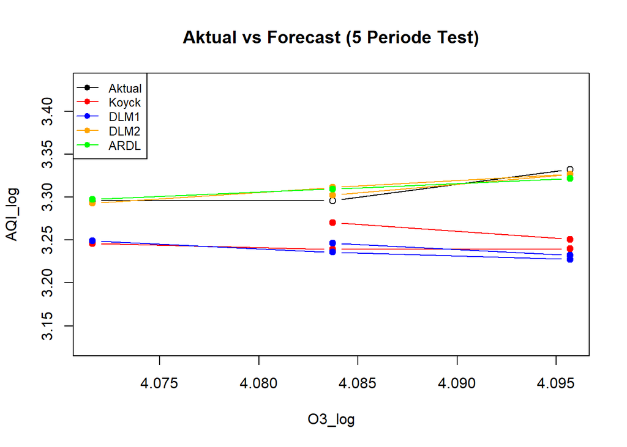

```r
# Ambil subset aktual (5 titik pertama test set)
y_actual <- test$AQI_log[1:5]
x_actual <- test$O3_log[1:5]

# Forecast dari semua model
y_koyck <- fore.koyck$forecasts
y_dlm1  <- fore.dlm$forecasts
y_dlm2  <- fore.dlm2$forecasts
y_ardl  <- fore.ardl$forecasts

# Plot aktual
plot(x_actual, y_actual, type="b", col="black", ylim=c(min(y_actual, y_koyck, y_dlm1, y_dlm2, y_ardl)-0.1,
                                                      max(y_actual, y_koyck, y_dlm1, y_dlm2, y_ardl)+0.1),
     xlab="O3_log", ylab="AQI_log", main="Aktual vs Forecast (5 Periode Test)")

# Tambahkan hasil forecast
lines(x_actual, y_koyck, col="red", type="b", pch=19)
lines(x_actual, y_dlm1,  col="blue", type="b", pch=19)
lines(x_actual, y_dlm2,  col="orange", type="b", pch=19)
lines(x_actual, y_ardl,  col="green", type="b", pch=19)

# Legend
legend("topleft", c("Aktual", "Koyck", "DLM1", "DLM2", "ARDL"),
       col=c("black","red","blue","orange","green"), lty=1, pch=19, cex=0.8)
```

Berdasarkan data plot dari perbandingan model, model DLM terlihat cenderung mirip dengan data aktual. Sehingga dapat disimpulkan bahwa DLM adalah model terbaik karena juga memiliki nilai MAPE terkecil.